# Reproducible Research: Peer Assessment 1

# Reproducible Research: Peer Assessment 1

## Loading and preprocessing the data

```r
library(ggplot2)
library(lubridate)
unzip(zipfile="repdata%2Fdata%2Factivity.zip")
activity <- read.csv("activity.csv")
str(activity)
```

```
## 'data.frame':    17568 obs. of  3 variables:
##  $ steps   : int  NA NA NA NA NA NA NA NA NA NA ...
##  $ date    : Factor w/ 61 levels "2012-10-01","2012-10-02",..: 1 1 1 1 1 1 1 1 1 1 ...
##  $ interval: int  0 5 10 15 20 25 30 35 40 45 ...
```

## What is mean total number of steps taken per day?

For this part of the assignment, you can ignore the missing values in the dataset:

1. Calculate the total number of steps taken per day.

```r
step_per_day <- aggregate(steps ~ date, data = activity, sum, na.rm = TRUE)
head(step_per_day)
```

|  | date | steps |
| --- | --- | --- |
| 1 | 2012-10-02 | 126 |
| 2 | 2012-10-03 | 11352 |
| 3 | 2012-10-04 | 12116 |
| 4 | 2012-10-05 | 13294 |
| 5 | 2012-10-06 | 15420 |
| 6 | 2012-10-07 | 11015 |

2. Make a histogram of the total number of steps taken each day.

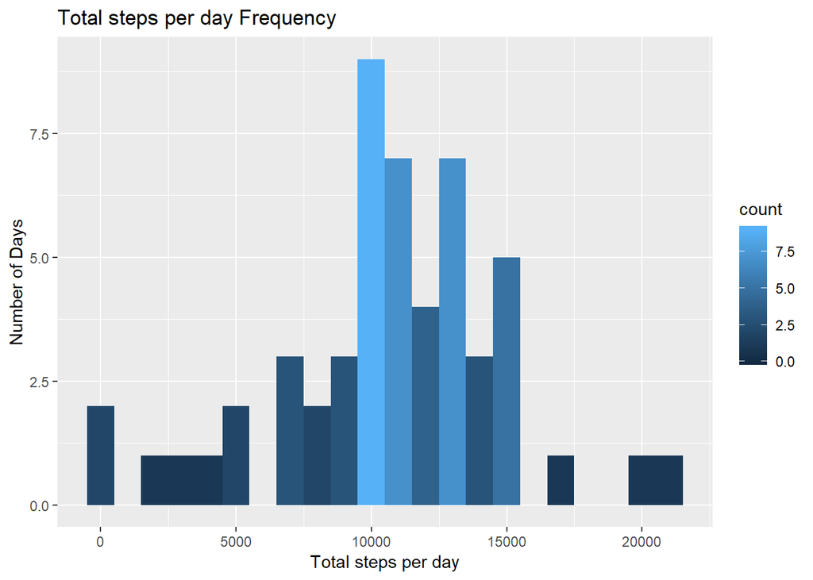

```r
ggplot(step_per_day, aes(x = steps)) +
  geom_histogram(aes(fill = ..count..), binwidth = 1000) +
  labs(title = "Total steps per day Frequency", x = "Total steps per day", y = "Number of Days")
```

3. Calculate and report the mean and median of the total number of steps taken per day.

```r
mean(step_per_day$steps)
```

```
## [1] 10766.19
```

```r
median(step_per_day$steps)
```

```
## [1] 10765
```

## What is the average daily activity pattern?

1. Make a time series plot (i.e. type = “l”) of the 5-minute interval (x-axis) and the average number of steps taken, averaged across all days (y-axis).

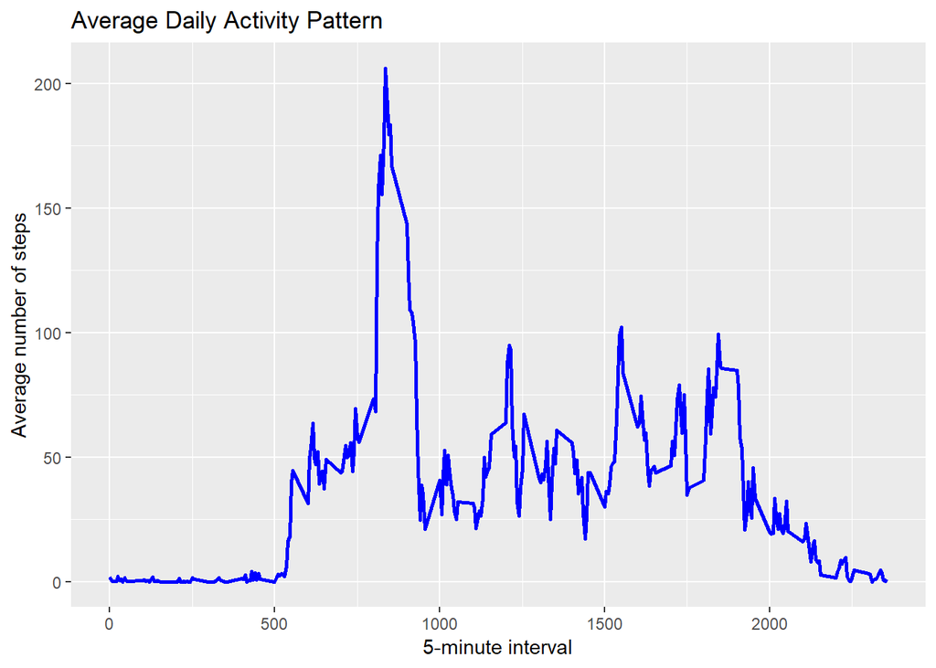

```r
avg_step <- aggregate(steps ~ interval, data = activity, mean, na.rm = TRUE)
ggplot(avg_step, aes(x = interval, y = steps)) +
  geom_line(col = "blue", size = 1) +
  labs(title = "Average Daily Activity Pattern", x = "5-minute interval", y = "Average number of steps")
```

2. Which 5-minute interval, on average across all the days in the dataset, contains the maximum number of steps?.

```r
avg_step$interval[which.max(avg_step$steps)]
```

```
## [1] 835
```